# In-Class Session 11: Matching and Synthetic Control

Econometrics I

This notebook goes with Lectures 11a (matching, `Fall/L9 - Quasi Experiments/L9d - Matching.pdf`) and 11b (synthetic control, `L10a - Synthetic Control.pdf`). It leaves you five short problems. The membership program is the one behind the matching slides (`Fall/L9 - Quasi Experiments/matching_sims.R`). The synthetic-control design is the one in the slides (`sdid_sims.R`, `conformal_sims.R`), which is *not* the Assignment 6 design. Everything is simulated, so you always know the right answer.

# Part 1: Selection on observables (Lecture 11a)

## Reproduce: a paid membership program

An online retailer sells a paid membership (free shipping, member prices). Customers choose whether to join, and the ones who join are heavier past spenders, have been customers longer, and use the app. The outcome is spending next quarter, in dollars. The effect of membership is larger for heavier spenders, so the ATT and the ATE differ.

Conditional independence holds *by construction*: membership depends only on the three observed covariates. `sel` scales how strongly past spending drives membership.

```r
sim_members <- function(N = 4000, sel = 1.2) {
  past <- rnorm(N, 0, 1)                         # standardized log past spend
  tenure <- rexp(N, 1 / 3)                       # years as a customer
  app <- rbinom(N, 1, 0.4)                       # uses the mobile app
  ps <- plogis(-1 + sel * past + 0.15 * tenure + 0.8 * app)
  D <- rbinom(N, 1, ps)
  tau_i <- 30 + 20 * past                        # heterogeneous effect, $ per quarter
  y0 <- 200 + 60 * past + 15 * past^2 + 5 * tenure + 20 * app + rnorm(N, 0, 40)
  data.frame(past, tenure, app, D, ps_true = ps, tau_i, y = y0 + tau_i * D)
}
m <- sim_members()
truth <- c(ATE = mean(m$tau_i), ATT = mean(m$tau_i[m$D == 1]))
truth
```

```
##      ATE      ATT
## 29.75488 39.60492
```

Balance before adjustment, in standardized differences (the slides’ $d_k$):

```r
std_diff <- function(x, D, w = rep(1, length(x))) {
  m1 <- weighted.mean(x[D == 1], w[D == 1]); m0 <- weighted.mean(x[D == 0], w[D == 0])
  (m1 - m0) / sqrt((var(x[D == 1]) + var(x[D == 0])) / 2)
}
covs <- c("past", "tenure", "app")
round(sapply(covs, function(v) std_diff(m[[v]], m$D)), 2)
```

```
##   past tenure    app
##   1.02   0.32   0.32
```

Estimators of the ATT and ATE. The propensity score is a logit on the three covariates. Matching is one nearest neighbor on the estimated score, with replacement. The regression-adjustment and AIPW outcome models fit each arm separately with a quadratic in past spending.

```r
m$ps <- fitted(glm(D ~ past + tenure + app, binomial, m))
treated <- which(m$D == 1); controls <- which(m$D == 0)

# 1-NN matching on the propensity score (ATT)
oc <- controls[order(m$ps[controls])]; pos <- findInterval(m$ps[treated], m$ps[oc])
lo <- oc[pmax(pos, 1)]; hi <- oc[pmin(pos + 1, length(oc))]
nn <- ifelse(abs(m$ps[lo] - m$ps[treated]) <= abs(m$ps[hi] - m$ps[treated]), lo, hi)
att_nn <- mean(m$y[treated] - m$y[nn])

# IPW (Hajek). ATT: controls weighted by ps / (1 - ps). ATE: both arms reweighted.
w_att <- ifelse(m$D == 1, 1, m$ps / (1 - m$ps))
att_ipw <- weighted.mean(m$y[treated], w_att[treated]) - weighted.mean(m$y[controls], w_att[controls])
w_ate <- ifelse(m$D == 1, 1 / m$ps, 1 / (1 - m$ps))
ate_ipw <- weighted.mean(m$y[treated], w_ate[treated]) - weighted.mean(m$y[controls], w_ate[controls])

# Outcome models by arm, then AIPW (ATE)
mu <- function(arm, f = y ~ past + I(past^2) + tenure + app) predict(lm(f, m[m$D == arm, ]), m)
mu1 <- mu(1); mu0 <- mu(0)
ate_ra <- mean(mu1 - mu0)
att_ra <- mean(m$y[treated] - mu0[treated])
aipw <- function(mu1, mu0, ps) mean(mu1 - mu0 + m$D * (m$y - mu1) / ps - (1 - m$D) * (m$y - mu0) / (1 - ps))
ate_aipw <- aipw(mu1, mu0, m$ps)

data.frame(
  estimator = c("Difference in means", "OLS: y on D + covariates (linear)", "1-NN on propensity score",
                "IPW (Hajek)", "Regression adjustment by arm", "IPW (Hajek)", "Regression adjustment by arm", "AIPW"),
  estimand = c("-", "-", "ATT", "ATT", "ATT", "ATE", "ATE", "ATE"),
  estimate = round(c(mean(m$y[treated]) - mean(m$y[controls]), coef(feols(y ~ D + past + tenure + app, m))["D"],
                     att_nn, att_ipw, att_ra, ate_ipw, ate_ra, ate_aipw), 1),
  truth = round(c(NA, NA, rep(truth["ATT"], 3), rep(truth["ATE"], 3)), 1))
```

```
##                           estimator estimand estimate truth
## 1               Difference in means        -    102.1    NA
## 2 OLS: y on D + covariates (linear)        -     31.5    NA
## 3          1-NN on propensity score      ATT     40.6  39.6
## 4                       IPW (Hajek)      ATT     40.2  39.6
## 5      Regression adjustment by arm      ATT     38.7  39.6
## 6                       IPW (Hajek)      ATE     32.6  29.8
## 7      Regression adjustment by arm      ATE     29.5  29.8
## 8                              AIPW      ATE     29.4  29.8
```

Each estimate carries sampling noise. Over 200 simulated samples, all six adjusted estimators are centered on their truth; their standard deviations run from about $1.5 (regression adjustment, AIPW) to $3 (matching), $4 (IPW for the ATE) and $7 (IPW for the ATT). Matching and weighting buy robustness to the outcome model at a price in variance.

Balance after weighting for the ATT:

```r
round(sapply(covs, function(v) std_diff(m[[v]], m$D, w_att)), 3)
```

```
##   past tenure    app
##  0.010  0.011  0.053
```

### Problem 1

The linear OLS regression controls for every confounder. In this draw it lands near the ATE, but over repeated samples it averages about $33, against an ATE of $30 and an ATT of $40. Give two reasons, using the data-generating process. (Hint: what is it missing in $E[Y(0) \mid X]$, and what weights does OLS put on the heterogeneous effects?) Then add `I(past^2)` to the OLS and check over 100 samples. Which problem does that fix, and which remains?

```r
# your code here
```

### Problem 2

Overlap. Re-simulate with `sel = 3`. Plot the estimated propensity score by treatment status, and report the largest ATE weight `max(w_ate)`. What happens to the IPW and AIPW estimates of the ATE, and why is the ATT less affected? Then trim to $0.1 \le \hat\pi \le 0.9$ (Crump et al. 2009) and re-estimate. What population is the trimmed estimate about, and is it still the ATE?

```r
# your code here
```

### Problem 3

Double robustness. Compute AIPW three ways: (i) a wrong outcome model (drop `I(past^2)` and fit both arms with `y ~ tenure + app`) with the correct propensity score; (ii) the correct outcome model with a wrong propensity score (`glm(D ~ tenure + app, ...)`); (iii) both wrong. Compare each to the ATE. Repeat over 100 simulated samples if you have time.

```r
# your code here
```

# Part 2: Synthetic control (Lecture 11b)

## Reproduce: a city soda tax

The design in the slides: one treated city, 40 donor cities, 24 quarters, and a tax that cuts per-capita sales by 10% from quarter 17. Sales follow a two-factor model; the treated city loads $0.75$ on the trend factor, inside the donors’ range. `alpha1` shifts the treated city’s *level*.

```r
sim_soda <- function(J = 40, Tq = 24, T0 = 16, mu1 = 0.75, alpha1 = 0, sd_alpha = 0) {
  lam <- cbind(seq(0, 2, length.out = Tq), rnorm(Tq))
  mu <- matrix(runif((J + 1) * 2), J + 1, 2); mu[1, ] <- c(mu1, 0.3)
  alpha <- c(alpha1, rnorm(J, 0, sd_alpha))
  Y <- 100 + matrix(alpha, Tq, J + 1, byrow = TRUE) + 5 * lam %*% t(mu) + matrix(rnorm(Tq * (J + 1)), Tq, J + 1)
  truth <- -0.1 * mean(Y[(T0 + 1):Tq, 1]); Y[(T0 + 1):Tq, 1] <- 0.9 * Y[(T0 + 1):Tq, 1]
  list(Y = Y, T0 = T0, truth = truth)           # Y is quarters x cities; city 1 is treated
}
sc_w <- function(y1, Y0) solve.QP(crossprod(Y0) + diag(1e-8, ncol(Y0)), crossprod(Y0, y1),
                                  cbind(1, diag(ncol(Y0))), c(1, rep(0, ncol(Y0))), meq = 1)$solution
s <- sim_soda(); Y <- s$Y; T0 <- s$T0; post <- (T0 + 1):nrow(Y)
w <- sc_w(Y[1:T0, 1], Y[1:T0, -1])
gap <- Y[, 1] - Y[, -1] %*% w
round(w[w > 0.05], 2)
```

```
## [1] 0.26 0.12 0.37 0.12 0.07
```

```r
c(sc = mean(gap[post]), truth = s$truth, pre_rmspe = sqrt(mean(gap[1:T0]^2)))
```

```
##          sc       truth   pre_rmspe
## -11.4415138 -10.5942676   0.7021895
```

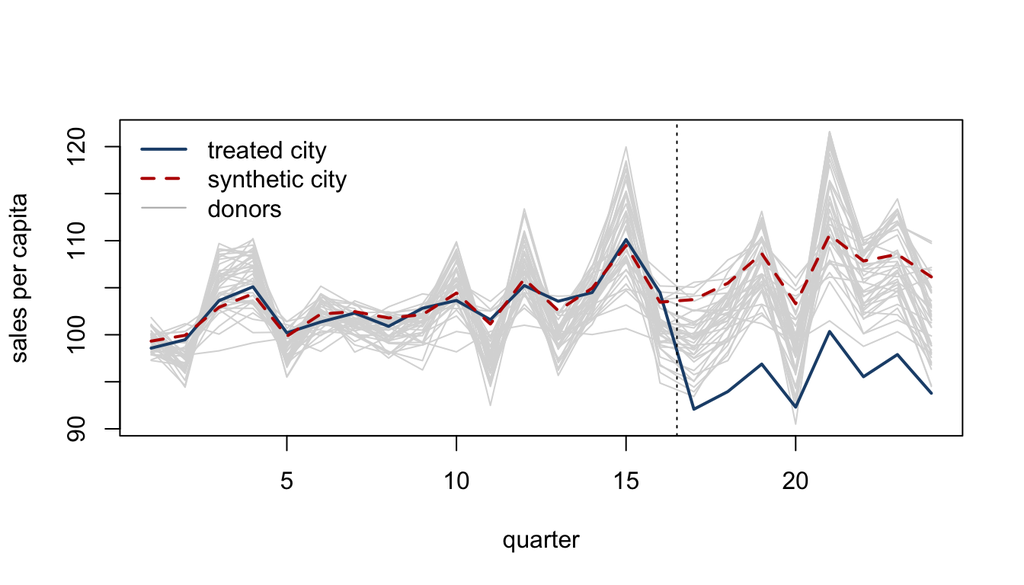

```r
matplot(Y, type = "l", lty = 1, col = "grey85", xlab = "quarter", ylab = "sales per capita")
lines(Y[, 1], lwd = 2, col = "#1f4e79"); lines(Y[, -1] %*% w, lwd = 2, lty = 2, col = "#bb0000")
abline(v = T0 + 0.5, lty = 3)
legend("topleft", bty = "n", legend = c("treated city", "synthetic city", "donors"),
       col = c("#1f4e79", "#bb0000", "grey70"), lwd = c(2, 2, 1), lty = c(1, 2, 1))
```

DiD, SC and synthetic DiD side by side with `synthdid` (which wants units in rows, controls first):

```r
three <- function(Y, T0) {
  Ys <- t(Y)[c(2:ncol(Y), 1), ]; N0 <- ncol(Y) - 1
  c(did = did_estimate(Ys, N0, T0), sc = sc_estimate(Ys, N0, T0), sdid = synthdid_estimate(Ys, N0, T0))
}
round(c(three(Y, T0), truth = s$truth), 2)
```

```
##    did     sc   sdid  truth
##  -9.83 -11.44 -11.49 -10.59
```

### Problem 4

Placebo in time. Pretend the tax started in quarter 11: fit the weights on quarters 1–10 only, and look at the gap in quarters 11–16, all of which are truly untreated. What should you find, and what do you find? What kind of failure would this test catch that the pre-period fit alone would not?

```r
# your code here
```

### Problem 5

Levels. Re-simulate with `alpha1 = 15, sd_alpha = 5`, so the treated city sits above every donor in level but not in trend. Compare DiD, SC and SDID to the truth, and look at SC’s pre-period fit. Which estimator handles the level, and which handles the trend? Repeat over 50 samples and report the bias of each.

```r
# your code here
```